[figure not shown]

# GES-NEWS

GEOSCIENCE, ENVIRONMENTAL SCIENCE, AND SUSTAINABILITY NEWS

Issue 2 · October 2026Hofstra University · Geology, Environment and Sustainability

News, Events, and Opportunities for Students

Nearest deadline

**Goldwater Scholarship, signed faculty letter due: 15 October**

## From the editor

This is the second issue of GES-NEWS, for students in the Department of Geology, Environment and Sustainability (GES) and in related subject areas. As with last month, this newsletter brings together deadlines, internships, scholarships, field trips, volunteer opportunities and news about courses and about the work faculty and students in this department are doing.

To keep receiving GES-NEWS, [subscribe here](https://forms.gle/6aEiKjStMLBgyqhNA). To send in an article or an item, see the last section.

## Closing soon

### Goldwater Scholarship: Meet Dr. Smylie by 15 OctoberScholarship

*Barry Goldwater Scholarship*  
**Signed faculty letter due 15 October**

The Barry Goldwater Scholarship supports undergraduates who intend a research career in the natural sciences, mathematics or engineering. Hofstra nominates its own candidates rather than students applying directly, and once Hofstra makes its campus selection, that decision is final: a student not chosen on campus cannot apply to the national competition.

To be considered this year, meet with **Dr. Matthew Smylie**, Hofstra’s Goldwater representative, and give him a signed faculty endorsement letter by 15 October. Hofstra expects a grade point average of at least 3.5 in your major and 3.25 overall, and research experience after high school is required. Juniors are preferred over sophomores, and BS and BE degrees over BA.

Contact: Dr. Matthew Smylie. Details: [sites.google.com/hofstra.edu/prestigious-scholarships](https://sites.google.com/hofstra.edu/prestigious-scholarships/scholarship-listings/stem)

### Submit Your Abstract for New York CityConference

*American Association of Geographers (AAG) Annual Meeting 2027*  
**Abstracts close 15 October**

The national meeting of the American Association of Geographers comes to the Hilton Midtown in New York City, 8 to 12 February 2027. Students may submit an abstract to present a poster or a paper, or attend without presenting.

Register and pay as an AAG member before submitting an abstract (about $248 as of October 2026); non-members pay far more. The meeting includes the World Geography Bowl, a quiz competition for teams of students, and a “Community Zone” with career panels and workshops.

Details: [aag.org/events/aag2027](https://www.aag.org/events/aag2027/)

### Three Years, Fully FundedFellowship

*NSF Graduate Research Fellowship Program (GRFP)*  
**Geosciences closes 23 October 2026, 8:00 PM Eastern Time**

Three years of funded graduate study, applied for in your final year of college, before you have been admitted anywhere. It pays a $37,000 stipend each year and $16,000 towards the cost of education, for three years that you can use at any point within a five-year window of graduate study.

It is open to students in their final year, recent graduates, and first-year graduate students who are citizens, nationals or permanent residents of the United States. Second-year graduate students are not eligible.

Apply: [nsf.gov/funding/opportunities/grfp](https://www.nsf.gov/funding/opportunities/grfp-nsf-graduate-research-fellowship-program)

### A Week Inside Brookhaven National LaboratoryEvent

*Mini-Semester Program, 4 to 8 January 2027*  
**Apply by 28 October, 5:00 PM Eastern Time**

One week at the national laboratory in Upton, Long Island, with laboratory tours and hands-on activities, to introduce students to its research and to internships at the laboratories of the United States Department of Energy. The 2027 week is on machine learning with power grid data. Students travel there each day: housing and transport are not provided.

It is for college students (or graduates of the past year) aged 18 or over, majoring in a science, technology, engineering or mathematics subject, with a grade point average of at least 3.0, who are citizens or permanent residents of the United States. You also need health insurance and a REAL ID (a United States identity card that meets federal security rules) to enter the site. The application needs an essay of under 500 words naming three of the laboratory’s research areas, and two recommendation letters, at least one from a professor in one of these subjects, due 30 October, 11:59 PM Eastern Time. After you apply, you receive a link to send to the people writing your letters.

Apply: [online application](https://surveys.external.bnl.gov/n/MiniSemesterAppMachLearnPwrGridDataForm.aspx). Details: [bnl.gov/education](https://www.bnl.gov/education/programs/program.php?q=117). Questions: sgonzalez@bnl.gov

### A Paid Field Season, If the Chair Nominates YouFellowship

*National Association of Geoscience Teachers and United States Geological Survey Cooperative Summer Field Training Fellowship*  
**Chair’s nomination deadline 30 October**

Up to five months of paid field, laboratory or office research with a United States Geological Survey mentor, for students finishing, or who finished within the last six months, a geoscience degree after a capstone such as field camp, a senior project or a thesis. It pays at the federal GS-5, Step 1 rate, with help toward moving costs. United States citizenship is required.

The department chair nominates, not the student, and Dr. Bennington has confirmed Hofstra will nominate this year. The programme’s web page still carries a note from 2025: because of the federal pause on hiring, the Survey will decide later whether to invite nominated students to apply. Every nominated student receives a certificate of nomination either way.

Contact: Dr. J Bret Bennington. Details: nagt.org/nagt/students/usgs_field.html

### Gilbert Hanson Memorial Geosciences ScholarshipScholarship

*Long Island Association of Professional Geologists*  
**Closes 1 November 2026, 11:59 PM**

One thousand to three thousand dollars for a junior or senior geoscience major at a Nassau or Suffolk County school, with at least 30 credit hours of geoscience coursework completed by graduation. A one-time award; past recipients cannot reapply.

The application needs the online application form, plus a faculty letter, a personal statement, a resume and an unofficial transcript, combined into one PDF.

Apply: email the package to LIAPGPRES@gmail.com. Details: liapg.org/scholarship

## On and Near Campus Events

### Real Jobs, Real AlumniEvent

*Alumni career talks in the course GEOL 005*  
**15 and 22 October**

The three alumni career talks announced last issue are still ahead. GES students are welcome:

- Marrakech Cunliffe, sustainability (Thursday 15 October, 12:30 PM)
- Doug Ferraiolo, hydrology, more than a decade in the field (Thursday 22 October, 11:30 AM)
- Francesca Grassia, environmental geology  
  (Thursday 22 October, 12:30 PM)

Gittleson 162. For more information, write to Dr. Farmer (GEOECF@hofstra.edu).

### Reading History in Tree RingsEvent

*Science Night Live, with the Hofstra Cultural Center and this department*  
**Tuesday 20 October, 6:30 to 8:00 PM Eastern Time. Free; register in advance**

Dr. Neil Pederson explains how scientists read the history stored in trees through tree-ring analysis, and how it tracks environmental change, including in old-growth forests. It is in person, in the Helene Fortunoff Theater, Monroe Lecture Center, South Campus, and open to the public.

To register, call the Hofstra Cultural Center on 516-463-5669. Details: [news.hofstra.edu](https://news.hofstra.edu/event/science-night-live-ancient-trees-bring-new-knowledge-in-our-rapidly-changing-world/)

### Solving Global Problems LocallyConference

*A conference of the University of Amsterdam and Hofstra University*  
**Monday 26 and Tuesday 27 October, from 9:00 AM. Free; sign up to attend**

The conference connects students and faculty to exchange knowledge and perspectives on shared local and societal challenges. On Monday (9:00 AM to 12:00 PM), Dr. Sasha Pesci of this department speaks on a panel, on food access and sustainable agriculture. On Tuesday (9:00 to 11:00 AM), students present their projects: Renee Lista, a graduate student in the department, presents hers, on food access in Roosevelt, New York.

It takes place in the Cultural Center Theater at Hofstra and on Zoom. Sign up for either one on the same form; the Zoom link is sent after you sign up.

[Sign up here](https://uvaforms.formstack.com/forms/uva_hofstra_placemaking_event). Details: [uva.nl](https://www.uva.nl/en/education/exchange/partner-university-events/placemaking-event/placemaking-event)

### Present Your Research on CampusEvent

*Fall 2026 Undergraduate Research and Creativity Day*  
**Thursday 10 December. Your faculty mentor registers you by 16 November**

A poster session for undergraduates from every department, 11:30 AM to 1:00 PM in the Student Center Multipurpose Rooms, with creative performances and projects from 2:00 to 4:00 PM in the Guthart Cultural Center Theater. It suits a poster already shown at a conference, an honors thesis, or another advanced research project. Posters are 36 by 48 inches; the Hofstra print shop prints them, unmounted, for $45 each.

Ask the professor you work with: professors register students, not students themselves.

## Off Campus Events

### A Day With the Native Plant InitiativeEvent

*Long Island Native Plant Initiative, at the Sisters of St. Joseph, Brentwood, New York*  
**Saturday 24 October, 9:00 AM to 2:00 PM**

A day of volunteer restoration work with the Long Island Native Plant Initiative. Depart from the Gittleson Hall loading dock at 9:00 AM. Contact: Dr. Bennington.

[Sign up](https://docs.google.com/spreadsheets/d/1Vq4e7XZeo6RoaB8MEn0TtSrAuGN2Mnemv8cbygp0cm8/edit?usp=sharing)

### Present Your Research at RutgersConference

*Rutgers Climate Symposium 2026, Douglass Student Center, New Brunswick, New Jersey*  
**Wednesday 18 November. Abstracts close 9 November, registration closes 12 November**

A day of plenary talks and panel discussions on climate research, followed by a poster session where students present their own work. Talks run from 9:00 AM to 12:30 PM and the poster session from 1:30 to 3:00 PM. It is free for students, faculty and staff from any academic institution.

To present a poster, submit an abstract by 9 November. To attend without presenting, register by 12 November.

[Details and registration](https://ruclimatesymposium.rutgers.edu/)

### Free Dinner, Real GeologistsEvent

*Long Island Association of Professional Geologists*  
**Next dinner meeting in early December. The date is not set yet**

The association holds a dinner meeting every quarter, with talks and panel discussions on geoscience research topics and on working in environmental and geotechnical consulting. It sponsors up to five students at each meeting, so those students eat for free, and the department can usually arrange a van from campus. Dr. Bennington coordinates attendance and transportation.

## One of Ours

### What a Rock Looks Like Inside

By David Persaud

*The rock laboratory has two new machines, funded by the department chair, Dr. J Bret Bennington: a Hi-Tech Diamond trim saw, which cuts a rock open, and an All-U-Need flat lap polisher, which smooths the cut face until the minerals show. David Persaud, a student in the department, has been using them.*

[video not shown]

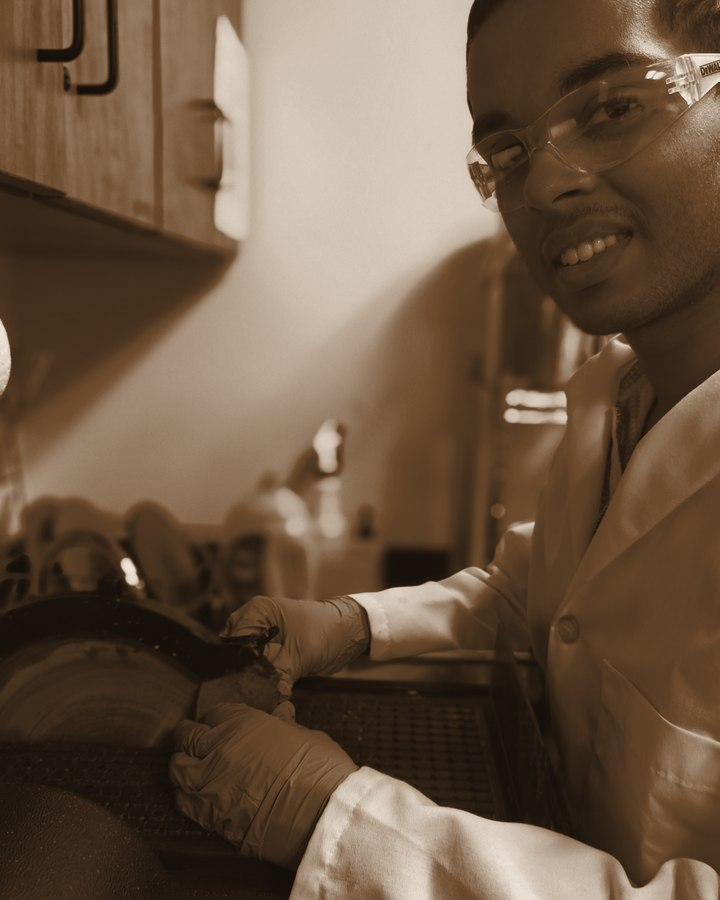

hover to play

The surface of a rock does not always tell you much, since years of weathering and erosion wear it down. Sawing a rock open reveals the true form of the rock: the minerals inside, grouped in patterns called assemblages that point to what kind of rock you are holding. Once you make the first cut, you keep sawing until the piece is around the size of a key, and then begin polishing. A polished face looks like a granite countertop: you can see every crystal, its shape, size and colour. That is where the rock finally tells you its story. For example, I am working on a piece of iron ore, which had a surface of dull greys and reds of indistinguishable minerals. Once I polished it, the face showed a bigger variety of minerals, and had a bright, metallic shine.

*The saw and the polisher are in the rock laboratory in Gittleson Hall. Students working with a faculty mentor on an independent study or a research project can use them. Ask in your Geology, Environment and Sustainability course, or write to the department office.*

### My Summer with the Birds

By Renee Lista

*Renee Lista, a graduate student in the department’s Sustainability program, spent her summer protecting shorebirds on Lido Beach.*

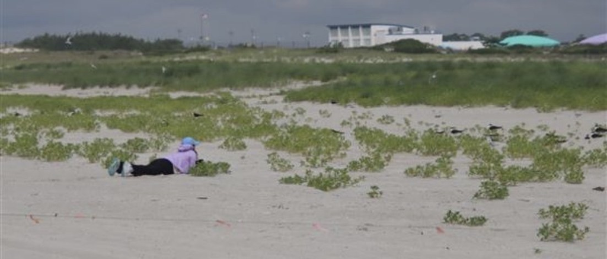

**Fig.** Renee Lista lies on the sand to read the leg bands of black skimmers, about 15 feet (4.5 metres) in front of her, on Lido Beach.

From June through September, I interned with the Town of Hempstead Department of Conservation and Waterways, protecting endangered and threatened birds.

On a quad on Lido Beach, I spent my days monitoring piping plovers and black skimmers (our main focus, but I monitored all shorebirds), maintaining field logs and surveys, conducting banding resights, protecting beach habitat, engaging with the public, and supporting projects. These projects included bird banding, water sampling, invasive plant management, and the diamondback terrapin project.

The hardest part of the role was seeing how vicious a hungry bird can be; watching gulls prey on chicks was devastating. I left this internship with a new love for birds, months of hands-on wildlife conservation experience, and relationships I know I’ll carry with me for years to come.

*Students interested in a 2027 seasonal position with the Town of Hempstead Department of Conservation and Waterways can send a letter of interest and a resume to Tara Schneider-Moran (CW-volunteers@hempsteadny.gov).*

## Academic Calendar and Other Dates to Know

- **19 October (seniors and graduate students), 21 October (juniors), 26 October (sophomores), 28 October (freshmen), all at 1:30 PM:** Spring 2027 registration opens, by class standing. A selection of Spring courses is below.
- **1 November (Sunday):** deadline to apply for graduation for inclusion in the mid-year commencement book.
- **8 November (Sunday):** last day for undergraduate students to withdraw from a single course (not from all courses).
- **25 to 29 November:** Thanksgiving break, classes not in session.

Checked against Hofstra’s own calendar, 27 September 2026 ([hofstra.edu/academics/calendar/fall-2026](https://www.hofstra.edu/academics/calendar/fall-2026/)), and the Spring 2027 registration dates against the Spring 2027 calendar, 12 October 2026.

### Spring 2027 Courses in GES

A selection from Dr. Bennington’s Spring 2027 course guide, emailed to every GES student on 8 October; the guide also says which degree requirement each course meets. The GEOL 121 lecture and GEOL 142 times below differ from the guide; they are the official times now. WI marks a Writing Intensive course; STEAM stands for science, technology, engineering, arts and mathematics.

| Course | Instructor | Days and times |
| --- | --- | --- |
| GEOL 002 Historical Geology (WI) | Bennington | Tue, Thu 2:40–4:35 PM |
| GEOL 015 Global Climate Change | Bernhardt | Mon, Wed 2:40–4:35 PM |
| GEOL 020 Introduction to Field Methods | Farmer | Tue, Thu 12:00–2:25 PM |
| GEOL 121 Hydrology | Bennington | Wed, Fri 9:10–10:05 AM; laboratory Fri 11:30 AM–2:25 PM |
| GEOL 142 Geostatistics | Marsellos | Mon, Wed 10:10 AM–12:35 PM |
| HUHC 020E Community Engaged Sustainability | Marsellos | Fri 9:30 AM–12:30 PM |
| SBLY 002 Sustainability Planning and Policy | Bernhardt | Tue, Thu 9:40–11:05 AM |
| SBLY 025 Communicating the Climate Change Crisis | Young | Mon, Wed 2:40–4:05 PM |
| SBLY 120 Sustainability and Food | Pesci | Tue, Thu 9:40–11:05 AM |
| WST 150A STEAM Careers for Everyone (WI) | Farmer | Mon, Fri 11:20 AM–12:45 PM |

HUHC 020E is a seminar of the Hofstra University Honors College; students outside the Honors College may join by invitation: ask Dr. Marsellos (antonios.marsellos@hofstra.edu). Graduate students cannot count undergraduate courses towards their degree. For advice on which courses to take: Dr. Bennington (j.b.bennington@hofstra.edu) for undergraduates, Dr. Jase Bernhardt (jase.e.bernhardt@hofstra.edu) for graduate students.

### The GES LinkedIn Group

GES has a LinkedIn group, “Hofstra Geology, Environment, & Sustainability”: graduates, current students and faculty. Internships and jobs are posted there, many of them by Dr. Farmer, one of the group’s administrators. The group is private: ask to join, and current and former GES students are approved. Questions: Dr. Farmer (GEOECF@hofstra.edu).

Join: [linkedin.com/groups/8660377](https://www.linkedin.com/groups/8660377/)

## Looking to next summer

The summer positions below are decided in the winter, but the application work starts now.

### A Paid Summer on a Sustainability TeamInternship

*Green Teams, PSEG Institute for Sustainability Studies, Montclair State University, summer 2027*  
**Closes 29 January 2027**

Eleven weeks of full-time, paid work in a team of five students, on a sustainability project set by a host organisation. It is for undergraduates in their later years, from any major and any university; an exceptional first-year student may also be considered, and seniors graduating before August 2027 are not eligible. It runs from 24 May to 5 August 2027 with a planned $7,500 stipend, and on-campus housing is available on request.

Details: inside.montclair.edu/pseg_iss. Apply: [application form](https://forms.gle/pUPnMHrfPezpXGDA6)

### Two Years of Paid StudyScholarship

*Hollings Undergraduate Scholarship*  
**Closes 31 January 2027, 11:59 PM Eastern Time**

Two years of support for your studies, up to $9,500 each year, and a paid summer research internship at a facility of the National Oceanic and Atmospheric Administration (NOAA).

**You must be one of these:** a full-time second-year student in a four-year programme, a full-time third-year student in a five-year programme, or a community college (a two-year college) or transfer student who is applying to a four-year institution. You must be a citizen of the United States and hold a cumulative grade point average of at least 3.0.

Apply: [noaa.gov/office-education/hollings-scholarship](https://www.noaa.gov/office-education/hollings-scholarship/prospective)

### Summer Job: National ParkInternship

*Scientists in Parks, summer 2027*  
**Applications open in mid-December**

A paid placement in a national park doing real resource work: geological mapping, monitoring, geographic information systems, and explaining the park’s science to visitors, in parks across the United States.

Details: scientistsinparks.org/how-to-apply

### Paid Research, an Hour AwayInternship

*Lamont-Doherty Summer Intern Program*  
**2027 dates not posted yet. Watch from early January**

Ten weeks of paid summer research in Earth, ocean, atmospheric and environmental science at Lamont-Doherty Earth Observatory in Palisades, New York, about an hour from campus. The 2026 round paid a $7,000 stipend with free accommodation in a hall of residence.

Details: [lamont.columbia.edu](https://lamont.columbia.edu/education-outreach/student-summer-opportunities-intern-programs)

## Write for GES-NEWS

GES-NEWS is looking for student contributing editors, whose names are printed at the top of every issue they work on.

What contributors write:

- A first-person account of an internship, a field season, or a summer project
- Your own research finding, written so that a first-year student understands it
- A report from an event, a field trip or a conference, with photographs
- Anything about student life in GES that other students would want to know

None of it is scientific writing.

“It is writing for people outside your subject, which is a separate skill and a useful one to have.”

To contribute a piece, or to join as a contributing editor for the year, write to the editor, antonios.marsellos@hofstra.edu, with GES-NEWS in the subject line.

**How the dates are checked.** Every application deadline in this issue was checked on the website of the organisation that offers it, and all of them were checked again on 12 October 2026. If an organisation has not posted next year’s deadline yet, as with the Lamont-Doherty summer internship, this newsletter says “not posted yet”. It does not print last year’s date, because that application is already closed. Some scholarships are not applied for directly: the university nominates you, so there is an internal Hofstra deadline months before the national one, as with the Goldwater Scholarship above.

GES-NEWS is published for students of the Department of Geology, Environment and Sustainability at Hofstra University, nine issues a year, September to May. If you find an error, write to the editor (antonios.marsellos@hofstra.edu) and it will be corrected in the next issue.

Founding Editor: Dr. Antonios E. Marsellos.  
Co-Editor: Dr. J Bret Bennington.  
Contributors to this issue: Dr. Jase Bernhardt, Dr. E. Christa Farmer, David Persaud, Renee Lista, Dr. Sasha Pesci.